# hw3

# c:

I would not recommend my model, I do not like the fact that the model is over fitted and that my box plot indicates a lot of points outside of the box, indicating a bad prediction. Also I am worried about some key variables not being a non zero, in any case the complexity of the model and amount of nonzero coef is an alarm for concern with the model.

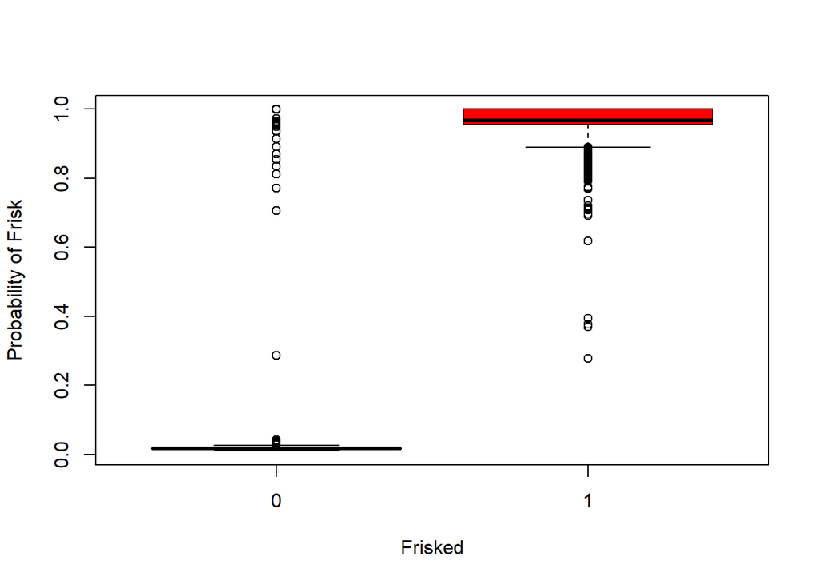

```r
# Question 3

# a
pred <- drop(predict(cv.lasso_model_10$gamlr, cv.X, type = "response"))
boxplot(pred ~ data_omit_seach_PF$FRISKED, xlab="Frisked", ylab="Probability of Frisk", col=c("blue","red"))
```

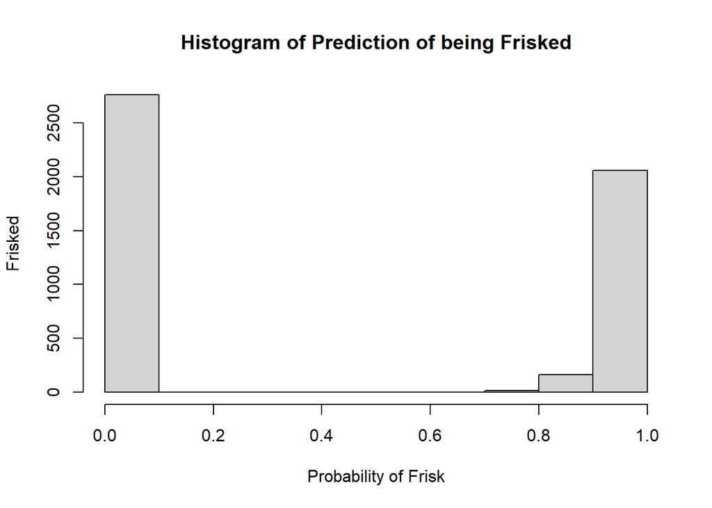

```r
hist(pred, main = "Histogram of Prediction of being Frisked", xlab="Probability of Frisk", ylab="Frisked")
```

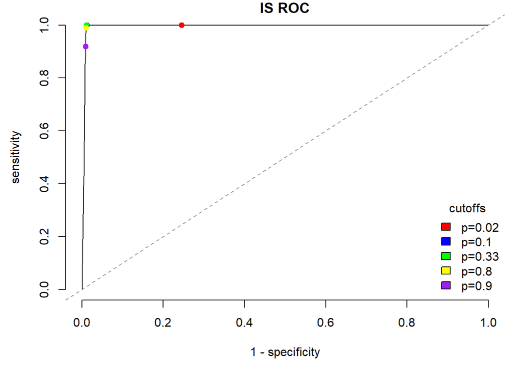

```r
# b
source("~/ECON124/Homework 3/roc.R")
par(mai=c(.9,.9,.2,.1)) # format margins
roc(pred, data_omit_seach_PF$FRISKED, bty="n", main="IS ROC")

points(x=1-mean((pred<=.02)[data_omit_seach_PF$FRISKED==0]), y=mean((pred>.02)[data_omit_seach_PF$FRISKED==1]), cex=1.5, pch=20, col='red')
points(x=1-mean((pred<=.1)[data_omit_seach_PF$FRISKED==0]), y=mean((pred>.1)[data_omit_seach_PF$FRISKED==1]), cex=1.5, pch=20, col='blue')
points(x=1-mean((pred<=0.33)[data_omit_seach_PF$FRISKED==0]), y=mean((pred>0.33)[data_omit_seach_PF$FRISKED==1]), cex=1.5, pch=20, col='green')
points(x=1-mean((pred<=0.8)[data_omit_seach_PF$FRISKED==0]), y=mean((pred>0.8)[data_omit_seach_PF$FRISKED==1]), cex=1.5, pch=20, col='yellow')
points(x=1-mean((pred<=0.9)[data_omit_seach_PF$FRISKED==0]), y=mean((pred>0.9)[data_omit_seach_PF$FRISKED==1]), cex=1.5, pch=20, col='purple')

legend("bottomright",fill=c("red","blue", "green", "yellow", "purple"), legend=c("p=0.02","p=0.1", "p=0.33", "p=0.8", "p=0.9"),bty="n",title="cutoffs")
```

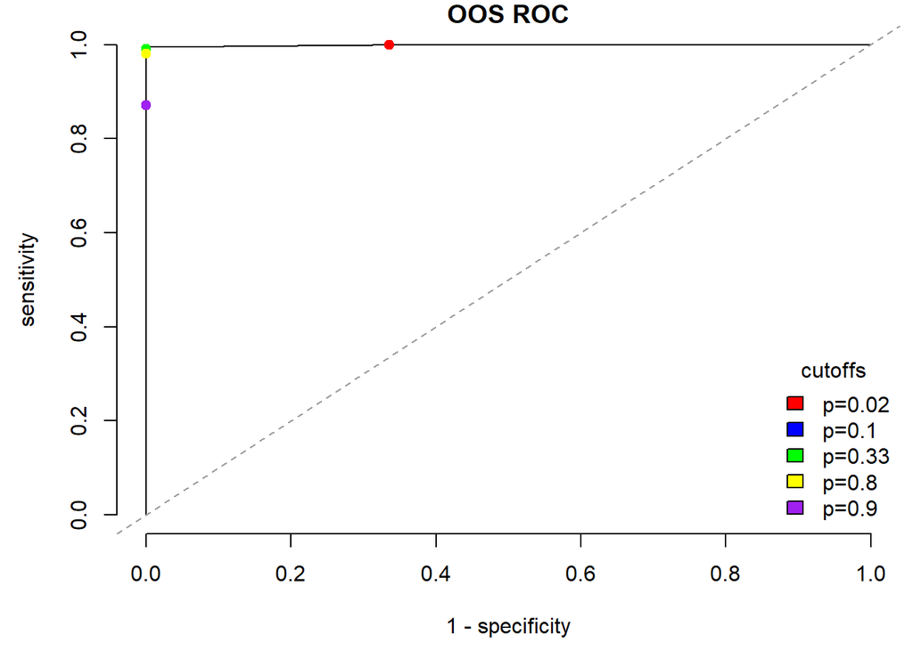

```r
set.seed(0)
test <- sample.int(1000,500)
lasso_model_half <- gamlr(cv.X[-test,], data_omit_seach_PF$FRISKED[-test], family = "binomial")
pred_oos <- predict(lasso_model_half, cv.X[test,], type="response")
Y_oos <- data_omit_seach_PF$FRISKED[test]
roc(pred_oos, Y_oos, bty="n", main="OOS ROC")

points(x=1-mean((pred_oos<=.02)[Y_oos==0]), y=mean((pred_oos>.02)[Y_oos==1]), cex=1.5, pch=20, col='red')
points(x=1-mean((pred_oos<=.1)[Y_oos==0]), y=mean((pred_oos>.1)[Y_oos==1]), cex=1.5, pch=20, col='blue')
points(x=1-mean((pred_oos<=0.33)[Y_oos==0]), y=mean((pred_oos>0.33)[Y_oos==1]), cex=1.5, pch=20, col='green')
points(x=1-mean((pred_oos<=0.8)[Y_oos==0]), y=mean((pred_oos>0.8)[Y_oos==1]), cex=1.5, pch=20, col='yellow')
points(x=1-mean((pred_oos<=0.9)[Y_oos==0]), y=mean((pred_oos>0.9)[Y_oos==1]), cex=1.5, pch=20, col='purple')
legend("bottomright",fill=c("red","blue", "green", "yellow", "purple"), legend=c("p=0.02","p=0.1", "p=0.33", "p=0.8", "p=0.9"),bty="n",title="cutoffs")
```